# R Notebook

#### 1) Load the packages

```r
library(ggplot2)
library(plyr)
library(gridExtra)
library(gmodels)
library(grid)
library(vcd)
library(scales)
library(ggthemes)
library(knitr)
```

```r
getwd()
```

```
[1] "/Users/angelfelipemagnossaodepaula/Desktop/R project"
```

#### 2)Downloading and Reading the Data

```r
setwd("/Users/angelfelipemagnossaodepaula/Desktop/R project")
```

```r
if(!file.exists("./adult.data")){

  fileUrl <- "https://archive.ics.uci.edu/ml/machine-learning-databases/adult/adult.data"

  download.file(fileUrl, destfile = "./adult.data")
}
```

```r
db.adult <- read.table("adult.data", sep = ",", header = FALSE)
```

#### 3) Overview of the Data

```r
dim(db.adult)[1] ## observation (lines)
```

```
[1] 32561
```

```r
dim(db.adult)[2] ## variables (columnd)
```

```
[1] 15
```

```r
colnames(db.adult) <- c("age", "workclass", "fnlwgt",
                        "education", "education_num",
                        "marital_status", "occupation",
                        "relationship", "race", "sex",
                        "capital_gain", "capital_loss",
                        "hours_per_week", "native_country", "income")
```

```r
head(db.adult, 10)
```

|  | age | workclass | fnlwgt | education | education_num | marital_status | occupation | relationship | race | sex | capital_gain | capital_loss | hours_per_week | native_country | income |
| --- | --- | --- | --- | --- | --- | --- | --- | --- | --- | --- | --- | --- | --- | --- | --- |
| 1 | 39 | State-gov | 77516 | Bachelors | 13 | Never-married | Adm-clerical | Not-in-family | White | Male | 2174 | 0 | 40 | United-States | <=50K |
| 2 | 50 | Self-emp-not-inc | 83311 | Bachelors | 13 | Married-civ-spouse | Exec-managerial | Husband | White | Male | 0 | 0 | 13 | United-States | <=50K |
| 3 | 38 | Private | 215646 | HS-grad | 9 | Divorced | Handlers-cleaners | Not-in-family | White | Male | 0 | 0 | 40 | United-States | <=50K |
| 4 | 53 | Private | 234721 | 11th | 7 | Married-civ-spouse | Handlers-cleaners | Husband | Black | Male | 0 | 0 | 40 | United-States | <=50K |
| 5 | 28 | Private | 338409 | Bachelors | 13 | Married-civ-spouse | Prof-specialty | Wife | Black | Female | 0 | 0 | 40 | Cuba | <=50K |
| 6 | 37 | Private | 284582 | Masters | 14 | Married-civ-spouse | Exec-managerial | Wife | White | Female | 0 | 0 | 40 | United-States | <=50K |
| 7 | 49 | Private | 160187 | 9th | 5 | Married-spouse-absent | Other-service | Not-in-family | Black | Female | 0 | 0 | 16 | Jamaica | <=50K |
| 8 | 52 | Self-emp-not-inc | 209642 | HS-grad | 9 | Married-civ-spouse | Exec-managerial | Husband | White | Male | 0 | 0 | 45 | United-States | >50K |
| 9 | 31 | Private | 45781 | Masters | 14 | Never-married | Prof-specialty | Not-in-family | White | Female | 14084 | 0 | 50 | United-States | >50K |
| 10 | 42 | Private | 159449 | Bachelors | 13 | Married-civ-spouse | Exec-managerial | Husband | White | Male | 5178 | 0 | 40 | United-States | >50K |

```r
str(db.adult)
```

```
'data.frame':   32561 obs. of  15 variables:
 $ age           : int  39 50 38 53 28 37 49 52 31 42 ...
 $ workclass     : Factor w/ 9 levels " ?"," Federal-gov",..: 8 7 5 5 5 5 5 7 5 5 ...
 $ fnlwgt        : int  77516 83311 215646 234721 338409 284582 160187 209642 45781 159449 ...
 $ education     : Factor w/ 16 levels " 10th"," 11th",..: 10 10 12 2 10 13 7 12 13 10 ...
 $ education_num : int  13 13 9 7 13 14 5 9 14 13 ...
 $ marital_status: Factor w/ 7 levels " Divorced"," Married-AF-spouse",..: 5 3 1 3 3 3 4 3 5 3 ...
 $ occupation    : Factor w/ 15 levels " ?"," Adm-clerical",..: 2 5 7 7 11 5 9 5 11 5 ...
 $ relationship  : Factor w/ 6 levels " Husband"," Not-in-family",..: 2 1 2 1 6 6 2 1 2 1 ...
 $ race          : Factor w/ 5 levels " Amer-Indian-Eskimo",..: 5 5 5 3 3 5 3 5 5 5 ...
 $ sex           : Factor w/ 2 levels " Female"," Male": 2 2 2 2 1 1 1 2 1 2 ...
 $ capital_gain  : int  2174 0 0 0 0 0 0 0 14084 5178 ...
 $ capital_loss  : int  0 0 0 0 0 0 0 0 0 0 ...
 $ hours_per_week: int  40 13 40 40 40 40 16 45 50 40 ...
 $ native_country: Factor w/ 42 levels " ?"," Cambodia",..: 40 40 40 40 6 40 24 40 40 40 ...
 $ income        : Factor w/ 2 levels " <=50K"," >50K": 1 1 1 1 1 1 1 2 2 2 ...
```

### As we can see from the output above, the variables “age”, “fnlwgt”, “education_num”, “capital_gain”, “capital_loss” and “hours_per_week” are of type integer, whereas all the other variables are factor variables with different number of levels. In order to see what the levels of each factor variable are, we write the function “levels_factors()”, which takes as an argument a data frame, identifies the factor variables and prints the levels of each categorical variable:

```r
levels_factor <- function(mydata){
  col_names <- names(mydata)
  for (i in 1:length(col_names)) {
    if(is.factor(mydata[, col_names[i]])) {
      message(noquote(paste("Covariante", " *", col_names[i],"* ","with factor level:",sep="")))

      print(levels(mydata[, col_names[i]]))
    }
  }
}
levels_factor(db.adult)
```

```
Covariante *workclass* with factor level:
```

```
[1] " ?"                " Federal-gov"      " Local-gov"        " Never-worked"     " Private"
[6] " Self-emp-inc"     " Self-emp-not-inc" " State-gov"        " Without-pay"
```

```
Covariante *education* with factor level:
```

```
 [1] " 10th"         " 11th"         " 12th"         " 1st-4th"      " 5th-6th"      " 7th-8th"
 [7] " 9th"          " Assoc-acdm"   " Assoc-voc"    " Bachelors"    " Doctorate"    " HS-grad"
[13] " Masters"      " Preschool"    " Prof-school"  " Some-college"
```

```
Covariante *marital_status* with factor level:
```

```
[1] " Divorced"              " Married-AF-spouse"     " Married-civ-spouse"    " Married-spouse-absent"
[5] " Never-married"         " Separated"             " Widowed"
```

```
Covariante *occupation* with factor level:
```

```
 [1] " ?"                 " Adm-clerical"      " Armed-Forces"      " Craft-repair"
 [5] " Exec-managerial"   " Farming-fishing"   " Handlers-cleaners" " Machine-op-inspct"
 [9] " Other-service"     " Priv-house-serv"   " Prof-specialty"    " Protective-serv"
[13] " Sales"             " Tech-support"      " Transport-moving"
```

```
Covariante *relationship* with factor level:
```

```
[1] " Husband"        " Not-in-family"  " Other-relative" " Own-child"      " Unmarried"
[6] " Wife"
```

```
Covariante *race* with factor level:
```

```
[1] " Amer-Indian-Eskimo" " Asian-Pac-Islander" " Black"              " Other"
[5] " White"
```

```
Covariante *sex* with factor level:
```

```
[1] " Female" " Male"
```

```
Covariante *native_country* with factor level:
```

```
 [1] " ?"                          " Cambodia"                   " Canada"
 [4] " China"                      " Columbia"                   " Cuba"
 [7] " Dominican-Republic"         " Ecuador"                    " El-Salvador"
[10] " England"                    " France"                     " Germany"
[13] " Greece"                     " Guatemala"                  " Haiti"
[16] " Holand-Netherlands"         " Honduras"                   " Hong"
[19] " Hungary"                    " India"                      " Iran"
[22] " Ireland"                    " Italy"                      " Jamaica"
[25] " Japan"                      " Laos"                       " Mexico"
[28] " Nicaragua"                  " Outlying-US(Guam-USVI-etc)" " Peru"
[31] " Philippines"                " Poland"                     " Portugal"
[34] " Puerto-Rico"                " Scotland"                   " South"
[37] " Taiwan"                     " Thailand"                   " Trinadad&Tobago"
[40] " United-States"              " Vietnam"                    " Yugoslavia"
```

```
Covariante *income* with factor level:
```

```
[1] " <=50K" " >50K"
```

#### From the output above we notice that some of the factor variables have a level denoted by " ?“. According to the documentation provided for the census dataset, the values marked with” ?" are missing values.

#### 4) Cleaning Missing Values

```r
db.adult <- read.table("adult.data", sep = ",", header = FALSE, na.strings = " ?")
colnames(db.adult) <- c("age", "workclass", "fnlwgt", "education",
                        "education_num", "marital_status", "occupation",
                        "relationship", "race", "sex", "capital_gain",
                        "capital_loss", "hours_per_week", "native_country", "income")
```

After we marked the missing values, we can clean them with the function “na.omit()” which deletes all rows (i.e. observations) containig missing values:

```r
db.adult <- na.omit(db.adult)
```

and after that we re-enumerate the rows of the data frame:

```r
row.names(db.adult) <- 1:nrow(db.adult)
```

```r
dim(db.adult)[1]
```

```
[1] 30162
```

#### 5) Transformations on the Data

#### 5.1) The variable “hours_per_week”

```r
summary(db.adult$hours_per_week)
```

```
   Min. 1st Qu.  Median    Mean 3rd Qu.    Max.
   1.00   40.00   40.00   40.93   45.00   99.00
```

From the box plot we also observe that there are a lot of outliers:

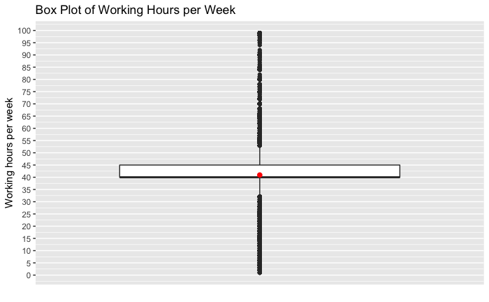

```r
ggplot(aes(x = factor(0), y = hours_per_week),
       data = db.adult) +
  geom_boxplot() +
  stat_summary(fun.y = mean,
               geom = 'point',
               shape = 19,
               color = "red",
               cex = 2) +
  scale_x_discrete(breaks = NULL) +
  scale_y_continuous(breaks = seq(0, 100, 5)) +
  xlab(label = "") +
  ylab(label = "Working hours per week") +
  ggtitle("Box Plot of Working Hours per Week")
```

Therefore, we will group the working hours in 5 categories which we consider relevant:

less than 40 hours per week between 40 and 45 hours per week between 45 and 60 hours per week between 60 and 80 hours per week, and more than 80 hours per week, and we will create a new factor variable called “hours_w” with 5 levels corresponding to these 5 categories:

```r
head(db.adult)
```

|  | age | workclass | fnlwgt | education | education_num | marital_status | occupation | relationship | race | sex | capital_gain | capital_loss | hours_per_week | native_country | income |
| --- | --- | --- | --- | --- | --- | --- | --- | --- | --- | --- | --- | --- | --- | --- | --- |
| 1 | 39 | State-gov | 77516 | Bachelors | 13 | Never-married | Adm-clerical | Not-in-family | White | Male | 2174 | 0 | 40 | United-States | <=50K |
| 2 | 50 | Self-emp-not-inc | 83311 | Bachelors | 13 | Married-civ-spouse | Exec-managerial | Husband | White | Male | 0 | 0 | 13 | United-States | <=50K |
| 3 | 38 | Private | 215646 | HS-grad | 9 | Divorced | Handlers-cleaners | Not-in-family | White | Male | 0 | 0 | 40 | United-States | <=50K |
| 4 | 53 | Private | 234721 | 11th | 7 | Married-civ-spouse | Handlers-cleaners | Husband | Black | Male | 0 | 0 | 40 | United-States | <=50K |
| 5 | 28 | Private | 338409 | Bachelors | 13 | Married-civ-spouse | Prof-specialty | Wife | Black | Female | 0 | 0 | 40 | Cuba | <=50K |
| 6 | 37 | Private | 284582 | Masters | 14 | Married-civ-spouse | Exec-managerial | Wife | White | Female | 0 | 0 | 40 | United-States | <=50K |

```r
db.adult$hours_w[db.adult$hours_per_week < 40 ] <- " less_than_40"
db.adult$hours_w[db.adult$hours_per_week >= 40 &
                   db.adult$hours_per_week <= 45 ] <- " between_40_and_45"
db.adult$hours_w[db.adult$hours_per_week > 45 &
                   db.adult$hours_per_week <= 60] <- " between_45_and_60"
db.adult$hours_w[db.adult$hours_per_week > 60 &
                   db.adult$hours_per_week <= 80] <- " between_60_and_80"
db.adult$hours_w[db.adult$hours_per_week > 80 ] <- " more_than_80"
```

In the latter we create the category " between_40_and_45" with greater than or equal and less than or equal sign, because we want the range of this category to correspond to the span of the data points between the first and the third quartile.

We want to make the new variable “hours_w” a factor variable, therefore we use the “factor()” function to do this:

```r
db.adult$hours_w <- factor(db.adult$hours_w,
                           ordered = FALSE,
                           levels = c(" less_than_40",
                                      " between_40_and_45",
                                      " between_45_and_60",
                                      " between_60_and_80",
                                      " more_than_80"))
```

```r
str(db.adult)
```

```
'data.frame':   30162 obs. of  16 variables:
 $ age           : int  39 50 38 53 28 37 49 52 31 42 ...
 $ workclass     : Factor w/ 8 levels " Federal-gov",..: 7 6 4 4 4 4 4 6 4 4 ...
 $ fnlwgt        : int  77516 83311 215646 234721 338409 284582 160187 209642 45781 159449 ...
 $ education     : Factor w/ 16 levels " 10th"," 11th",..: 10 10 12 2 10 13 7 12 13 10 ...
 $ education_num : int  13 13 9 7 13 14 5 9 14 13 ...
 $ marital_status: Factor w/ 7 levels " Divorced"," Married-AF-spouse",..: 5 3 1 3 3 3 4 3 5 3 ...
 $ occupation    : Factor w/ 14 levels " Adm-clerical",..: 1 4 6 6 10 4 8 4 10 4 ...
 $ relationship  : Factor w/ 6 levels " Husband"," Not-in-family",..: 2 1 2 1 6 6 2 1 2 1 ...
 $ race          : Factor w/ 5 levels " Amer-Indian-Eskimo",..: 5 5 5 3 3 5 3 5 5 5 ...
 $ sex           : Factor w/ 2 levels " Female"," Male": 2 2 2 2 1 1 1 2 1 2 ...
 $ capital_gain  : int  2174 0 0 0 0 0 0 0 14084 5178 ...
 $ capital_loss  : int  0 0 0 0 0 0 0 0 0 0 ...
 $ hours_per_week: int  40 13 40 40 40 40 16 45 50 40 ...
 $ native_country: Factor w/ 41 levels " Cambodia"," Canada",..: 39 39 39 39 5 39 23 39 39 39 ...
 $ income        : Factor w/ 2 levels " <=50K"," >50K": 1 1 1 1 1 1 1 2 2 2 ...
 $ hours_w       : Factor w/ 5 levels " less_than_40",..: 2 1 2 2 2 2 1 2 3 2 ...
 - attr(*, "na.action")= 'omit' Named int  15 28 39 52 62 70 78 94 107 129 ...
  ..- attr(*, "names")= chr  "15" "28" "39" "52" ...
```

```r
summary(db.adult$hours_w)
```

```
      less_than_40  between_40_and_45  between_45_and_60  between_60_and_80       more_than_80
              6714              16606               5790                857                195
```

```r
for (i in 1:length(summary(db.adult$hours_w))) {
  print(round(100*summary(db.adult$hours_w)[i]/sum(!is.na(db.adult$hours_w)),2))

}
```

```
 less_than_40
        22.26
 between_40_and_45
             55.06
 between_45_and_60
              19.2
 between_60_and_80
              2.84
 more_than_80
         0.65
```

As we can see, 55% of all people work between 40 and 45 hours a week, 22.3% work less than 40 hours, 19.2% work between 45 and 60 hours, 2.8% work between 60 and 80 hours, and 0.65% work more than 80 hours a week.

#### 5.2) The variable “native_country”

With the help of the “levels()” function, we can see that the factor variable “native_country” has 41 levels. If we build a (logistic regression) predictive model with “native_country” as a covariate, we will end up with 41 additional degrees of freedom due to this categorical variable. This will complicate unnecessarily the analysis and might lead to overfitting. Hence, it is better to group the native countries into several global regions. This coarsening of the data also makes the interpretation of the results easier to comprehend.

```r
levels(db.adult$native_country)
```

```
 [1] " Cambodia"                   " Canada"                     " China"
 [4] " Columbia"                   " Cuba"                       " Dominican-Republic"
 [7] " Ecuador"                    " El-Salvador"                " England"
[10] " France"                     " Germany"                    " Greece"
[13] " Guatemala"                  " Haiti"                      " Holand-Netherlands"
[16] " Honduras"                   " Hong"                       " Hungary"
[19] " India"                      " Iran"                       " Ireland"
[22] " Italy"                      " Jamaica"                    " Japan"
[25] " Laos"                       " Mexico"                     " Nicaragua"
[28] " Outlying-US(Guam-USVI-etc)" " Peru"                       " Philippines"
[31] " Poland"                     " Portugal"                   " Puerto-Rico"
[34] " Scotland"                   " South"                      " Taiwan"
[37] " Thailand"                   " Trinadad&Tobago"            " United-States"
[40] " Vietnam"                    " Yugoslavia"
```

Below we create the new variable “native_region”, where we group the countries by global regions. We first define the regions:

```r
Asia_East <- c(" Cambodia", " China", " Hong", " Laos", " Thailand",
               " Japan", " Taiwan", " Vietnam")
Asia_Central <- c(" India", " Iran")
Central_America <- c(" Cuba", " Guatemala", " Jamaica", " Nicaragua",
                     " Puerto-Rico",  " Dominican-Republic", " El-Salvador",
                     " Haiti", " Honduras", " Mexico", " Trinadad&Tobago")
South_America <- c(" Ecuador", " Peru", " Columbia")
Europe_West <- c(" England", " Germany", " Holand-Netherlands", " Ireland",
                 " France", " Greece", " Italy", " Portugal", " Scotland")
Europe_East <- c(" Poland", " Yugoslavia", " Hungary")
```

Then we modify the data frame by adding an additional column named “native_region”. We do this with the help of the “mutate” function form the “plyr” package:

```r
db.adult <- mutate(db.adult,
       native_region = ifelse(native_country %in% Asia_East, " East-Asia",
                ifelse(native_country %in% Asia_Central, " Central-Asia",
                ifelse(native_country %in% Central_America, " Central-America",
                ifelse(native_country %in% South_America, " South-America",
                ifelse(native_country %in% Europe_West, " Europe-West",
                ifelse(native_country %in% Europe_East, " Europe-East",
                ifelse(native_country == " United-States", " United-States",
                       " Outlying-US" ))))))))
```

Next we transform the new variable into a factor:

```r
db.adult$native_region <- factor(db.adult$native_region, ordered = FALSE)
```

```r
str(db.adult$native_region)
```

```
 Factor w/ 8 levels " Central-America",..: 8 8 8 8 1 8 1 8 8 8 ...
```

```r
head(db.adult, 20)
```

|  | age | workclass | fnlwgt | education | education_num | marital_status | occupation | relationship | race | sex | capital_gain | capital_loss | hours_per_week | native_country | income | hours_w | native_region |
| --- | --- | --- | --- | --- | --- | --- | --- | --- | --- | --- | --- | --- | --- | --- | --- | --- | --- |
| 1 | 39 | State-gov | 77516 | Bachelors | 13 | Never-married | Adm-clerical | Not-in-family | White | Male | 2174 | 0 | 40 | United-States | <=50K | between_40_and_45 | United-States |
| 2 | 50 | Self-emp-not-inc | 83311 | Bachelors | 13 | Married-civ-spouse | Exec-managerial | Husband | White | Male | 0 | 0 | 13 | United-States | <=50K | less_than_40 | United-States |
| 3 | 38 | Private | 215646 | HS-grad | 9 | Divorced | Handlers-cleaners | Not-in-family | White | Male | 0 | 0 | 40 | United-States | <=50K | between_40_and_45 | United-States |
| 4 | 53 | Private | 234721 | 11th | 7 | Married-civ-spouse | Handlers-cleaners | Husband | Black | Male | 0 | 0 | 40 | United-States | <=50K | between_40_and_45 | United-States |
| 5 | 28 | Private | 338409 | Bachelors | 13 | Married-civ-spouse | Prof-specialty | Wife | Black | Female | 0 | 0 | 40 | Cuba | <=50K | between_40_and_45 | Central-America |
| 6 | 37 | Private | 284582 | Masters | 14 | Married-civ-spouse | Exec-managerial | Wife | White | Female | 0 | 0 | 40 | United-States | <=50K | between_40_and_45 | United-States |
| 7 | 49 | Private | 160187 | 9th | 5 | Married-spouse-absent | Other-service | Not-in-family | Black | Female | 0 | 0 | 16 | Jamaica | <=50K | less_than_40 | Central-America |
| 8 | 52 | Self-emp-not-inc | 209642 | HS-grad | 9 | Married-civ-spouse | Exec-managerial | Husband | White | Male | 0 | 0 | 45 | United-States | >50K | between_40_and_45 | United-States |
| 9 | 31 | Private | 45781 | Masters | 14 | Never-married | Prof-specialty | Not-in-family | White | Female | 14084 | 0 | 50 | United-States | >50K | between_45_and_60 | United-States |
| 10 | 42 | Private | 159449 | Bachelors | 13 | Married-civ-spouse | Exec-managerial | Husband | White | Male | 5178 | 0 | 40 | United-States | >50K | between_40_and_45 | United-States |

[output cut: 10 more lines]

#### 5.3) The variables “capital_gain” and “capital_loss”

Now we are going to create two new categorical variables – “cap_gain” and “cap_loss”. We generate the new variables by grouping the existing variables “capital_gain” and “capital_loss” into three categories. We do this because there are too many zeros in the variables “capital_gain” and “capital_loss” and this can seriously disrupt the analysis.

From the summary below we see that at least 50% of the variables “capital_gain” and “capital_loss” are zeros.

```r
summary(db.adult$capital_gain)
```

```
   Min. 1st Qu.  Median    Mean 3rd Qu.    Max.
      0       0       0    1092       0   99999
```

```r
summary(db.adult$capital_loss)
```

```
   Min. 1st Qu.  Median    Mean 3rd Qu.    Max.
   0.00    0.00    0.00   88.37    0.00 4356.00
```

More precisely, the percentage of zeros in “capital_gain” is very big – 91.59%:

```r
(nrow(subset(db.adult, db.adult$capital_gain == 0))/nrow(db.adult))*100
```

```
[1] 91.58544
```

and the percentage of zeros in “capital_loss” is also very high – 95.27%:

```r
(nrow(subset(db.adult, db.adult$capital_loss== 0))/nrow(db.adult))*100
```

```
[1] 95.26888
```

```r
mean.gain <- mean(db.adult$capital_gain)
mean.loss <- mean(db.adult$capital_loss)
kable(data.frame(Mean_Capital_Gain = mean.gain, Mean_Capital_Loss = mean.loss),
      capital = "Mean Capital with Zero Values Included")
```

| Mean_Capital_Gain | Mean_Capital_Loss |
| --- | --- |
| 1092.008 | 88.37249 |

We give the mean capital gain and loss also in the case of all the zero values removed:

```r
mean.gain <- mean(subset(db.adult$capital_gain, db.adult$capital_gain > 0))
mean.loss <- mean(subset(db.adult$capital_loss, db.adult$capital_loss > 0))
kable(data.frame(Mean_Capital_Gain = mean.gain, Mean_Capital_Loss = mean.loss),
      capital = "Mean Capital with Zero Values Included")
```

| Mean_Capital_Gain | Mean_Capital_Loss |
| --- | --- |
| 12977.6 | 1867.898 |

Next we show a summary of the nonzero values of “capital_loss” and “capital_gain”, as well as their respective interquartile ranges (IQR):

```r
iqr.gain <- IQR(subset(db.adult$capital_gain, db.adult$capital_gain >0))
iqr.loss <- IQR(subset(db.adult$capital_loss, db.adult$capital_loss >0))
q.gain <- quantile(x = subset(db.adult$capital_gain, db.adult$capital_gain > 0),
                   probs = seq(0, 1, 0.25))
q.loss <- quantile(x = subset(db.adult$capital_loss, db.adult$capital_loss > 0),
                   probs = seq(0, 1, 0.25))
kable(x = data.frame(Capital_Gain = q.gain, Capital_Loss = q.loss),
      capital = "Quantiles of the Nonzero Capital")
```

|  | Capital_Gain | Capital_Loss |
| --- | --- | --- |
| 0% | 114 | 155 |
| 25% | 3464 | 1672 |
| 50% | 7298 | 1887 |
| 75% | 14084 | 1977 |
| 100% | 99999 | 4356 |

```r
kable(x = data.frame(IQR_Capital_Gain = iqr.gain, IQR_Capital_Loss= iqr.loss),
      caption = "IQR of the Nonzero Capital")
```

| IQR_Capital_Gain | IQR_Capital_Loss |
| --- | --- |
| 10620 | 305 |

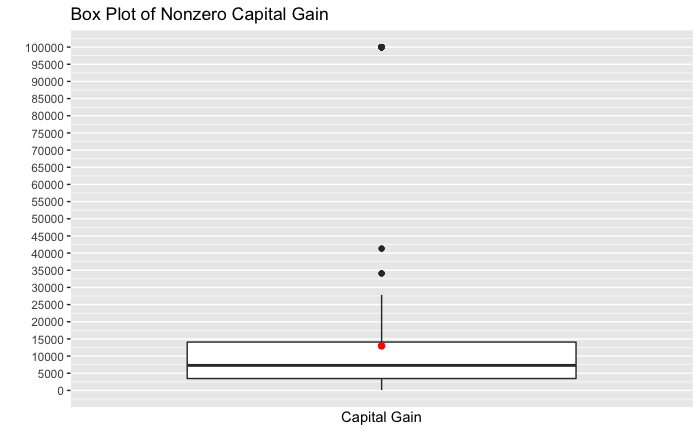

```r
ggplot(aes(x = factor(0), y = capital_gain),
       data = subset(db.adult, db.adult$capital_gain > 0)) +
  geom_boxplot() +
  stat_summary(fun.y = mean,
               geom = 'point',
               shape = 19,
               color = "red",
               cex = 2) +
  scale_x_discrete(breaks = NULL) +
  scale_y_continuous(breaks = seq(0, 100000, 5000)) +
  xlab(label = "Capital Gain") +
  ylab(label = "") +
  ggtitle("Box Plot of Nonzero Capital Gain")
```

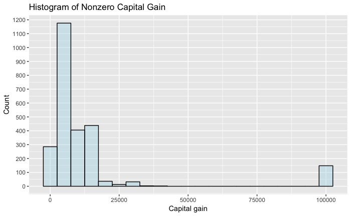

```r
df <- db.adult[db.adult$capital_gain > 0, ]
ggplot(data = df,
       aes(x = df$capital_gain))+
  geom_histogram(binwidth = 5000,
                 colour = "black",
                 fill = "lightblue",
                 alpha = 0.4) +
  scale_y_continuous(breaks = seq(0, 4000, 100)) +
  labs( x = "Capital gain", y = "Count" ) +
  ggtitle( "Histogram of Nonzero Capital Gain" )
```

The histogram confirms once more what we have already established, namely, that the majority of people with positive capital gain have a capital gain between 0 and 25,000 dollars, and there are also about 150 people with capital gain of around 100,000 dollars. We also note that the biggest number of people with positive capital gain are those with about 5,000 dollars.

Below is the box plot of the nonzero “capital_loss” values (the red dot marks the mean value):

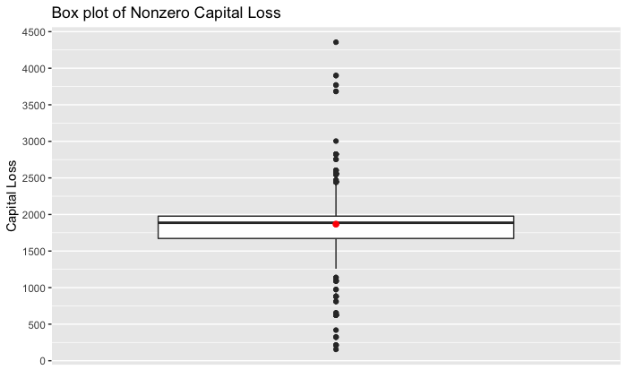

```r
ggplot(aes(x = factor(0), y = capital_loss),
       data = subset(db.adult, db.adult$capital_loss > 0)) +
  geom_boxplot() +
  stat_summary(fun.y = mean,
               geom = 'point',
               shape = 19,
               color = "red",
               cex = 2) +
  scale_x_discrete(breaks = NULL) +
  scale_y_continuous(breaks = seq(0, 5000, 500)) +
  ylab("Capital Loss") +
  xlab("") +
  ggtitle("Box plot of Nonzero Capital Loss")
```

We also display a histogram of the nonzero capital loss:

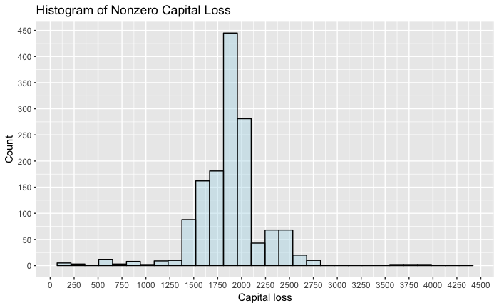

```r
df <- db.adult[db.adult$capital_loss > 0, ]
ggplot(data = df,
       aes(x = df$capital_loss)) +
  geom_histogram(colour = "black",
                 fill = "lightblue",
                 alpha = 0.4) +
  scale_x_continuous(breaks = seq(0, 5000, 250)) +
  scale_y_continuous(breaks = seq(0, 450, 50)) +
  labs(x = "Capital loss", y = "Count") +
  ggtitle("Histogram of Nonzero Capital Loss")
```

From the box plot we observe that most values are between 1,700 and 2,000 dollars (as already stated), and there are a lot of outliers represented by the filled black dots. From the histogram we also see that the biggest number of people have a capital loss of about 1,875 dollars.

The box plots and histograms illustrate visually the results of the summary statistics for the nonzero capital gain and capital loss. Based on these results, we will group the values of the variables “capital_loss” and “capital gain” into categories and we will create two new factor variables called “cap_gain” and “cap_loss”. We do the grouping in the following way:

Capital gain:

We use the function “mutate()”, together with “ifelse()” to create the new variables “cap_gain”

```r
db.adult <- mutate(db.adult,
                   cap_gain = ifelse (db.adult$capital_gain < 3464, " Low",
                              ifelse (db.adult$capital_gain >= 3464 &
                                      db.adult$capital_gain <= 14080, " Median", " High")))
db.adult$cap_gain <- factor(db.adult$cap_gain,
                                ordered = TRUE,
                                levels = c(" Low", " Medium", " High"))
```

```r
db.adult <- mutate(db.adult,
                   cap_loss = ifelse (db.adult$capital_loss < 1672, " Low",
                              ifelse (db.adult$capital_loss >= 1672 &
                                      db.adult$capital_loss <= 1977, " Median", " High")))
db.adult$cap_loss <- factor(db.adult$cap_loss,
                                ordered = TRUE,
                                levels = c(" Low", " Medium", " High"))
```

```r
str(db.adult)
```

[output not shown]

#### 5.4) The Variable “workclass”

With the help of the function “summary”, we notice that there is one unused factor level (i.e., there are no observations belonging to this level) in the variable “workclass”, namely the level “Never-worked”:

```r
summary(db.adult$workclass)
```

```
      Federal-gov         Local-gov      Never-worked           Private      Self-emp-inc
              943              2067                 0             22286              1074
 Self-emp-not-inc         State-gov       Without-pay
             2499              1279                14
```

As we can see from the output above, there are no participants in the survey who never worked in their lifetime. Therefore we remove the factor level “Never-worked” from the categorical variable “workclass”. We do this with the function “droplevels()”, which removes unused factor levels from a factor:

```r
db.adult$workclass <- droplevels(db.adult$workclass)
levels(db.adult$workclass)
```

```
[1] " Federal-gov"      " Local-gov"        " Private"          " Self-emp-inc"     " Self-emp-not-inc"
[6] " State-gov"        " Without-pay"
```

If we do not remove this unused level, we will most certainly have problems with zero cell counts when, for example, investigating if there exists some association between the categorical predictors.

#### 6) Preprocessing the Test Dataset

As we already clarified, the considered census data comes with a separate test data set, which we use to test the out-of-sample accuracy of the constructed predictive models.

In what follows we repeat the same steps as in the transformation of the training data frame “db.adult”.

First we read the test dataset:

```r
if(!file.exists("./adult.test")){

    fileUrl <- "https://archive.ics.uci.edu/ml/machine-learning-databases/adult/adult.test"

    download.file(fileUrl, destfile = "./adult.test")

}
```

```r
db.test <- read.table("/Users/angelfelipemagnossaodepaula/Desktop/R project/adult.test",
                      sep = ',',
                      header = FALSE,
                      skip = 1,
                      na.strings = " ?")
colnames(db.test) <-  c("age", "workclass", "fnlwgt", "education",
                       "education_num", "marital_status", "occupation",
                       "relationship", "race", "sex", "capital_gain",
                       "capital_loss", "hours_per_week",
                       "native_country", "income")
```

```r
head(db.test)
```

|  | age | workclass | fnlwgt | education | education_num | marital_status | occupation | relationship | race | sex | capital_gain | capital_loss | hours_per_week | native_country | income |
| --- | --- | --- | --- | --- | --- | --- | --- | --- | --- | --- | --- | --- | --- | --- | --- |
| 1 | 25 | Private | 226802 | 11th | 7 | Never-married | Machine-op-inspct | Own-child | Black | Male | 0 | 0 | 40 | United-States | <=50K. |
| 2 | 38 | Private | 89814 | HS-grad | 9 | Married-civ-spouse | Farming-fishing | Husband | White | Male | 0 | 0 | 50 | United-States | <=50K. |
| 3 | 28 | Local-gov | 336951 | Assoc-acdm | 12 | Married-civ-spouse | Protective-serv | Husband | White | Male | 0 | 0 | 40 | United-States | >50K. |
| 4 | 44 | Private | 160323 | Some-college | 10 | Married-civ-spouse | Machine-op-inspct | Husband | Black | Male | 7688 | 0 | 40 | United-States | >50K. |
| 5 | 18 | NA | 103497 | Some-college | 10 | Never-married | NA | Own-child | White | Female | 0 | 0 | 30 | United-States | <=50K. |
| 6 | 34 | Private | 198693 | 10th | 6 | Never-married | Other-service | Not-in-family | White | Male | 0 | 0 | 30 | United-States | <=50K. |

```r
db.test <- na.omit(db.test)
row.names(db.test) <- 1:nrow(db.test)
```

```r
head(db.test, 10)
```

|  | age | workclass | fnlwgt | education | education_num | marital_status | occupation | relationship | race | sex | capital_gain | capital_loss | hours_per_week | native_country | income |
| --- | --- | --- | --- | --- | --- | --- | --- | --- | --- | --- | --- | --- | --- | --- | --- |
| 1 | 25 | Private | 226802 | 11th | 7 | Never-married | Machine-op-inspct | Own-child | Black | Male | 0 | 0 | 40 | United-States | <=50K. |
| 2 | 38 | Private | 89814 | HS-grad | 9 | Married-civ-spouse | Farming-fishing | Husband | White | Male | 0 | 0 | 50 | United-States | <=50K. |
| 3 | 28 | Local-gov | 336951 | Assoc-acdm | 12 | Married-civ-spouse | Protective-serv | Husband | White | Male | 0 | 0 | 40 | United-States | >50K. |
| 4 | 44 | Private | 160323 | Some-college | 10 | Married-civ-spouse | Machine-op-inspct | Husband | Black | Male | 7688 | 0 | 40 | United-States | >50K. |
| 5 | 34 | Private | 198693 | 10th | 6 | Never-married | Other-service | Not-in-family | White | Male | 0 | 0 | 30 | United-States | <=50K. |
| 6 | 63 | Self-emp-not-inc | 104626 | Prof-school | 15 | Married-civ-spouse | Prof-specialty | Husband | White | Male | 3103 | 0 | 32 | United-States | >50K. |
| 7 | 24 | Private | 369667 | Some-college | 10 | Never-married | Other-service | Unmarried | White | Female | 0 | 0 | 40 | United-States | <=50K. |
| 8 | 55 | Private | 104996 | 7th-8th | 4 | Married-civ-spouse | Craft-repair | Husband | White | Male | 0 | 0 | 10 | United-States | <=50K. |
| 9 | 65 | Private | 184454 | HS-grad | 9 | Married-civ-spouse | Machine-op-inspct | Husband | White | Male | 6418 | 0 | 40 | United-States | >50K. |
| 10 | 36 | Federal-gov | 212465 | Bachelors | 13 | Married-civ-spouse | Adm-clerical | Husband | White | Male | 0 | 0 | 40 | United-States | <=50K. |

```r
str(db.adult$income)
```

```
 Factor w/ 2 levels " <=50K"," >50K": 1 1 1 1 1 1 1 2 2 2 ...
```

```r
str(db.test$income)
```

```
 Factor w/ 2 levels " <=50K."," >50K.": 1 1 2 2 1 2 1 1 2 1 ...
```

```r
levels(db.test$income)[1]<- " <=50k"
levels(db.test$income)[2]<- " >50k"
levels(db.test$income)
```

```
[1] " <=50k" " >50k"
```

Just as in the train data set - “db.adult”, we create a new variable called “hours_w”:

```r
db.test$hours_w[db.test$hours_per_week < 40] <- " less_than_40"
db.test$hours_w[db.test$hours_per_week >= 40 &
                db.test$hours_per_week <= 45] <- " between_40_and_45"
db.test$hours_w[db.test$hours_per_week > 45 &
                db.test$hours_per_week <= 60  ] <- " between_45_and_60"
db.test$hours_w[db.test$hours_per_week > 60 &
                db.test$hours_per_week <= 80  ] <- " between_60_and_80"
db.test$hours_w[db.test$hours_per_week > 80] <- " more_than_80"
db.test$hours_w <- factor(db.test$hours_w,
                          ordered = FALSE,
                          levels = c(" less_than_40",
                                     " between_40_and_45",
                                     " between_45_and_60",
                                     " between_60_and_80",
                                     " more_than_80"))
```

We also have to create the variable “native_region”, where we group the countries by global regions:

```r
db.test <- mutate(db.test,
       native_region = ifelse(native_country %in% Asia_East, " East-Asia",
                ifelse(native_country %in% Asia_Central, " Central-Asia",
                ifelse(native_country %in% Central_America, " Central-America",
                ifelse(native_country %in% South_America, " South-America",
                ifelse(native_country %in% Europe_West, " Europe-West",
                ifelse(native_country %in% Europe_East, " Europe-East",
                ifelse(native_country == " United-States", " United-States",
                       " Outlying-US" ))))))))
db.test$native_region <- factor(db.test$native_region, ordered = FALSE)
```

We have to create the variables “cap_gain” and “cap_loss” as well:

```r
db.test <- mutate(db.test,
            cap_gain = ifelse(db.test$capital_gain < 3464, " Low",
                       ifelse(db.test$capital_gain >= 3464 &
                              db.test$capital_gain <= 14080, " Medium", " High")))
db.test$cap_gain <- factor(db.test$cap_gain,
                            ordered = FALSE,
                            levels = c(" Low", " Medium", " High"))
```

```r
db.test<- mutate(db.test,
            cap_loss = ifelse(db.test$capital_loss < 1672, " Low",
                       ifelse(db.test$capital_loss >= 1672 &
                              db.test$capital_loss <= 1977, " Medium", " High")))
db.test$cap_loss <- factor(db.test$cap_loss,
                            ordered = FALSE,
                            levels = c(" Low", " Medium", " High"))
```

And, last, we drop the unused level “Never-worked” from the factor variable “workclass”:

```r
db.test$workclass <- droplevels(db.test$workclass)
```

#### 7) Exporting the Transformed Datasets

```r
write.csv(db.adult, "adult_df.csv", row.names = FALSE)
write.csv(db.test, "test_df.csv", row.names = FALSE)
```

```r
str(db.adult)
```

[output not shown]